# Report 8

Advay Vyas

March 09, 2026

# Introduction

This week, I will try to improve the time metrics per window and in general and also look at trends per state for magnitude and time metrics.

# Data loading

## Metric functions

```r
source("../metric_functions.R")
source("../graphstat_functions.R")
source("../write_dtw.R")
```

## Saved datasets

```r
hsa_state = read.csv("../hsa_state_inc.csv")
dtw_results = read_csv("../all_dtw_results.csv")
hsa_dtw = dtw_results |>
    left_join(hsa_state, by = join_by(ID == hsa_nci_id))
write_csv(unique(hsa_dtw), "../hsa_vs_state_metrics.csv")
all_metrics = read_csv("../hsa_vs_state_metrics.csv")
```

### Signed lag is backwards

I will rerun the code next week to fix this but for now I will implement something temporary to flip the signs (I did state leads HSA but it should have been HSA leads state).

```r
all_metrics = all_metrics |>
    mutate(signed_lag = -signed_lag)
```

# Window dataset

```r
hsa_unique = hsa_state %>%
    distinct(hsa_nci_id, state)
hsa_list = hsa_unique$hsa_nci_id

res = vector("list", length(hsa_list) * length(windows))
counter = 1

windows = list(w1 = c(1, 50), w2 = c(51, 100), w3 = c(101, Inf))

for (ID in hsa_list) {
    for (w in names(windows)) {

        bounds = windows[[w]]

        out = pivot_wider(dtw_stats(ID, start = bounds[1], end = bounds[2]),
            names_from = Metric, values_from = Value)

        out$ID = ID
        out$window = w

        res[[counter]] = out
        counter = counter + 1
    }
}

dtw_results_window = do.call(rbind, res)
```

```r
dtw_results_window$window = factor(as.numeric(sub("w", "", dtw_results_window$window)),
    levels = c(1, 2, 3))
dtw_results_window = dtw_results_window %>%
    rename(peak_window = window)
dtw_results_window$peak_window = as.numeric(dtw_results_window$peak_window)

glimpse(dtw_results_window)
```

```
## Rows: 2,016
## Columns: 13
## $ mean_abs_lag  <dbl> 0.7586207, 0.4727273, 0.3076923, 0.2545455, 2.3225806, 1…
## $ signed_lag    <dbl> -0.10344828, -0.14545455, 0.19230769, -0.18181818, -0.61…
## $ median_lag    <dbl> 0.0, 0.0, 0.0, 0.0, -1.0, 0.0, 0.0, 0.0, 0.0, -1.5, 0.0,…
## $ lag_sd        <dbl> 1.2238802, 0.6781834, 0.5253742, 0.5474151, 2.7061244, 1…
## $ dtw_mae       <dbl> 0.05482759, 0.06854545, 0.08673077, 0.39636364, 0.294838…
## $ dtw_rmse      <dbl> 0.1079591, 0.1067452, 0.1380983, 0.9109795, 0.4741750, 0…
## $ rmse          <dbl> 0.1278202, 0.1738850, 0.1711542, 1.0035367, 0.9885666, 0…
## $ amp_ratio     <dbl> 1.0841691, 1.0638344, 0.9729167, 0.7020994, 0.3223906, 0…
## $ dtw_amp_ratio <dbl> 1.0000000, 1.0000000, 0.9942529, 0.9166667, 0.7507225, 0…
## $ lag_amp_corr  <dbl> -0.1016802734, 0.1592453886, 0.1094562695, -0.0263533294…
## $ frechet       <dbl> 0.39, 0.28, 0.41, 3.50, 1.67, 1.16, 0.86, 0.61, 1.09, 0.…
## $ ID            <int> 688, 688, 688, 985, 985, 985, 795, 795, 795, 754, 754, 7…
## $ peak_window   <dbl> 1, 2, 3, 1, 2, 3, 1, 2, 3, 1, 2, 3, 1, 2, 3, 1, 2, 3, 1,…
```

## Ground truth

```r
all_metrics_modified = all_metrics |>
  mutate(week_index = (epi_week + (epi_year - 2022) * 52 - 38),
    peak_window = case_when(
      week_index <= 50  ~ 1,
      week_index <= 100 ~ 2,
      TRUE              ~ 3
  ))

peak_centroid = function(x, weeks, q = 0.80) {
  threshold = quantile(x, q, na.rm = TRUE)
  mask = x >= threshold & !is.na(x)
  if (sum(mask) == 0) return(NA_real_)
  weighted.mean(weeks[mask], x[mask])
}

truth_peaks =
  all_metrics_modified |>
  group_by(ID, state, peak_window) |>
  summarise(
    # HSA peak
    hsa_peak_week     = week_index[which.max(inc_hsa)],
    hsa_peak_value    = max(inc_hsa, na.rm = TRUE),
    hsa_centroid      = peak_centroid(inc_hsa, week_index),

    # State peak
    state_peak_week   = week_index[which.max(inc_state)],
    state_peak_value  = max(inc_state, na.rm = TRUE),
    state_centroid    = peak_centroid(inc_state, week_index),

    # Argmax differences (keep for comparison)
    truth_time_diff     = hsa_peak_week - state_peak_week,
    truth_time_diff_abs = abs(truth_time_diff),

    # Centroid difference (new)
    centroid_time_diff     = hsa_centroid - state_centroid,
    centroid_time_diff_abs = abs(centroid_time_diff),

    truth_mag_ratio = hsa_peak_value / state_peak_value,

    .groups = "drop"
  )

glimpse(truth_peaks)
```

```
## Rows: 2,013
## Columns: 14
## $ ID                     <dbl> 1, 1, 1, 2, 2, 2, 3, 3, 3, 4, 4, 4, 5, 5, 5, 7,…
## $ state                  <chr> "Maryland", "Maryland", "Maryland", "Kentucky",…
## $ peak_window            <dbl> 1, 2, 3, 1, 2, 3, 1, 2, 3, 1, 2, 3, 1, 2, 3, 1,…
## $ hsa_peak_week          <dbl> 10, 66, 125, 9, 74, 125, 9, 66, 125, 10, 75, 12…
## $ hsa_peak_value         <dbl> 7.78, 6.37, 8.94, 12.09, 8.08, 10.09, 8.71, 6.5…
## $ hsa_centroid           <dbl> 10.723016, 69.248591, 125.572292, 9.643232, 71.…
## $ state_peak_week        <dbl> 9, 66, 124, 9, 66, 124, 9, 66, 124, 10, 66, 124…
## $ state_peak_value       <dbl> 7.70, 6.31, 11.12, 13.19, 5.69, 14.00, 8.35, 5.…
## $ state_centroid         <dbl> 8.953904, 69.071133, 123.707275, 9.416102, 70.5…
## $ truth_time_diff        <dbl> 1, 0, 1, 0, 8, 1, 0, 0, 1, 0, 9, 0, 0, 0, -2, -…
## $ truth_time_diff_abs    <dbl> 1, 0, 1, 0, 8, 1, 0, 0, 1, 0, 9, 0, 0, 0, 2, 3,…
## $ centroid_time_diff     <dbl> 1.76911261, 0.17745794, 1.86501657, 0.22712955,…
## $ centroid_time_diff_abs <dbl> 1.76911261, 0.17745794, 1.86501657, 0.22712955,…
## $ truth_mag_ratio        <dbl> 1.0103896, 1.0095087, 0.8039568, 0.9166035, 1.4…
```

## DTW metrics by window dataset

```r
diff_peak_data = truth_peaks %>%
    left_join(dtw_results_window, by = c("ID", "peak_window"))

glimpse(diff_peak_data)
```

```
## Rows: 2,013
## Columns: 25
## $ ID                     <dbl> 1, 1, 1, 2, 2, 2, 3, 3, 3, 4, 4, 4, 5, 5, 5, 7,…
## $ state                  <chr> "Maryland", "Maryland", "Maryland", "Kentucky",…
## $ peak_window            <dbl> 1, 2, 3, 1, 2, 3, 1, 2, 3, 1, 2, 3, 1, 2, 3, 1,…
## $ hsa_peak_week          <dbl> 10, 66, 125, 9, 74, 125, 9, 66, 125, 10, 75, 12…
## $ hsa_peak_value         <dbl> 7.78, 6.37, 8.94, 12.09, 8.08, 10.09, 8.71, 6.5…
## $ hsa_centroid           <dbl> 10.723016, 69.248591, 125.572292, 9.643232, 71.…
## $ state_peak_week        <dbl> 9, 66, 124, 9, 66, 124, 9, 66, 124, 10, 66, 124…
## $ state_peak_value       <dbl> 7.70, 6.31, 11.12, 13.19, 5.69, 14.00, 8.35, 5.…
## $ state_centroid         <dbl> 8.953904, 69.071133, 123.707275, 9.416102, 70.5…
## $ truth_time_diff        <dbl> 1, 0, 1, 0, 8, 1, 0, 0, 1, 0, 9, 0, 0, 0, -2, -…
## $ truth_time_diff_abs    <dbl> 1, 0, 1, 0, 8, 1, 0, 0, 1, 0, 9, 0, 0, 0, 2, 3,…
## $ centroid_time_diff     <dbl> 1.76911261, 0.17745794, 1.86501657, 0.22712955,…
## $ centroid_time_diff_abs <dbl> 1.76911261, 0.17745794, 1.86501657, 0.22712955,…
## $ truth_mag_ratio        <dbl> 1.0103896, 1.0095087, 0.8039568, 0.9166035, 1.4…
## $ mean_abs_lag           <dbl> 1.6119403, 2.1194030, 2.0163934, 6.8732394, 2.6…
## $ signed_lag             <dbl> -0.14925373, 0.56716418, 0.44262295, -6.7042253…
## $ median_lag             <dbl> 0, 0, 1, -5, 0, 0, 0, 0, 0, 0, 0, 0, -2, -2, -1…
## $ lag_sd                 <dbl> 2.0980058, 2.8774140, 2.3203778, 6.9104359, 3.7…
## $ dtw_mae                <dbl> 0.17686567, 0.18059701, 0.31360656, 0.14028169,…
## $ dtw_rmse               <dbl> 0.34035320, 0.31147698, 0.53469311, 0.29517243,…
## $ rmse                   <dbl> 1.27743806, 0.47127274, 1.67159791, 0.43770767,…
## $ amp_ratio              <dbl> 0.0000000, 0.5159484, 0.3382101, 0.3981900, 0.4…
## $ dtw_amp_ratio          <dbl> 0.7333333, 0.9117647, 0.8183673, 0.8916968, 0.8…
## $ lag_amp_corr           <dbl> 0.08660950, -0.37544901, 0.05472684, -0.4142402…
## $ frechet                <dbl> 1.57, 1.05, 2.18, 1.42, 2.39, 3.91, 1.28, 0.91,…
```

# Time

```r
diff_peak_time = diff_peak_data |>
    filter(!is.na(centroid_time_diff) & !is.na(signed_lag))
```

```r
timing_cor_table = diff_peak_time |>
    group_by(peak_window) |>
    summarise(cor_mean_abs_lag = cor(truth_time_diff_abs, mean_abs_lag,
        use = "complete.obs"), cor_signed_lag = cor(truth_time_diff,
        signed_lag, use = "complete.obs"), cor_median_lag = cor(truth_time_diff,
        median_lag, use = "complete.obs"), cor_lag_sd = cor(truth_time_diff,
        lag_sd, use = "complete.obs"), .groups = "drop")
print(timing_cor_table)
```

```
## # A tibble: 3 × 5
##   peak_window cor_mean_abs_lag cor_signed_lag cor_median_lag cor_lag_sd
##         <dbl>            <dbl>          <dbl>          <dbl>      <dbl>
## 1           1            0.263          0.151          0.193    0.0499
## 2           2            0.288          0.451          0.417    0.216
## 3           3            0.395          0.429          0.472   -0.00579
```

```r
timing_cor_table2 = diff_peak_time |>
    group_by(peak_window) |>
    summarise(cor_centroid_signed = cor(centroid_time_diff, signed_lag,
        use = "complete.obs"), cor_centroid_abs = cor(centroid_time_diff_abs,
        mean_abs_lag, use = "complete.obs"), cor_centroid_median = cor(centroid_time_diff,
        median_lag, use = "complete.obs"), .groups = "drop")
print(timing_cor_table2)
```

```
## # A tibble: 3 × 4
##   peak_window cor_centroid_signed cor_centroid_abs cor_centroid_median
##         <dbl>               <dbl>            <dbl>               <dbl>
## 1           1               0.280            0.283               0.327
## 2           2               0.588            0.560               0.609
## 3           3               0.617            0.531               0.674
```

```r
centroid_lm = lm(centroid_time_diff ~ signed_lag * factor(peak_window),
    data = diff_peak_time)
summary(centroid_lm)
```

```
##
## Call:
## lm(formula = centroid_time_diff ~ signed_lag * factor(peak_window),
##     data = diff_peak_time)
##
## Residuals:
##     Min      1Q  Median      3Q     Max
## -7.2472 -0.8352 -0.0874  0.7641 30.3455
##
## Coefficients:
##                                 Estimate Std. Error t value Pr(>|t|)
## (Intercept)                      0.90979    0.07365  12.354  < 2e-16 ***
## signed_lag                       0.21261    0.02203   9.650  < 2e-16 ***
## factor(peak_window)2            -0.62765    0.10354  -6.062 1.61e-09 ***
## factor(peak_window)3            -0.58848    0.10430  -5.642 1.92e-08 ***
## signed_lag:factor(peak_window)2  0.62915    0.05087  12.368  < 2e-16 ***
## signed_lag:factor(peak_window)3  0.52006    0.06336   8.208 4.01e-16 ***
## ---
## Signif. codes:  0 '***' 0.001 '**' 0.01 '*' 0.05 '.' 0.1 ' ' 1
##
## Residual standard error: 1.877 on 1974 degrees of freedom
## Multiple R-squared:  0.2365, Adjusted R-squared:  0.2346
## F-statistic: 122.3 on 5 and 1974 DF,  p-value: < 2.2e-16
```

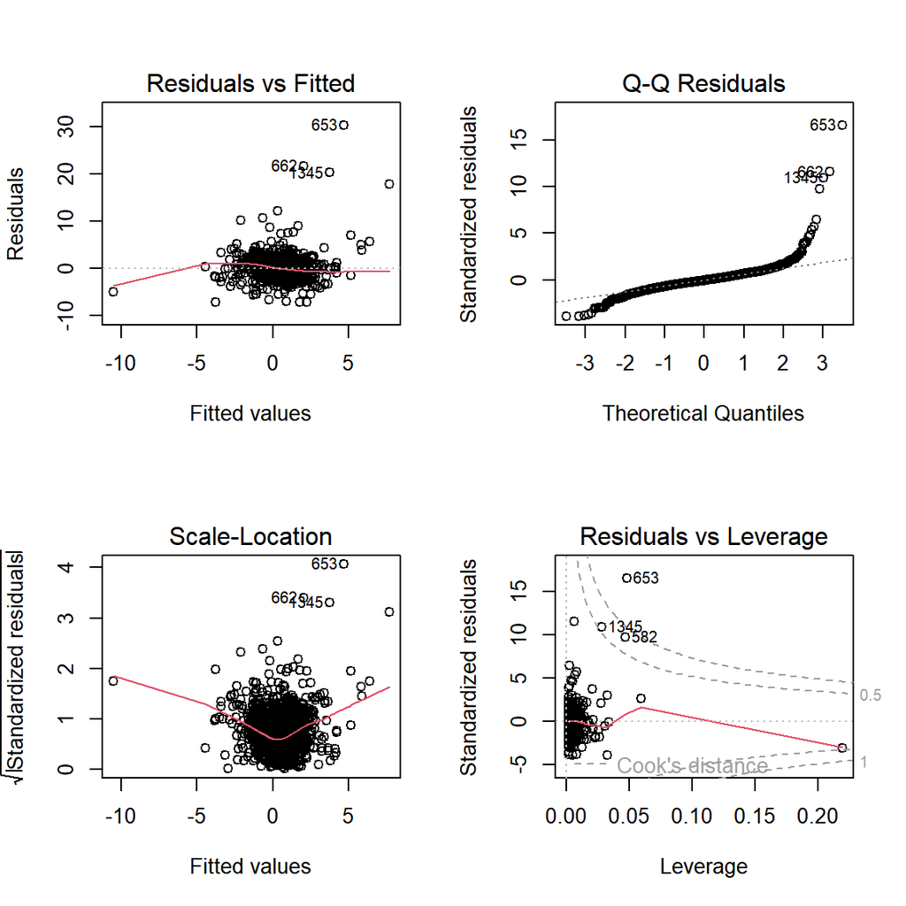

```r
par(mfrow = c(2, 2))
plot(centroid_lm)
```

```r
diff_peak_time$pred = predict(centroid_lm, newdata = diff_peak_time)
```

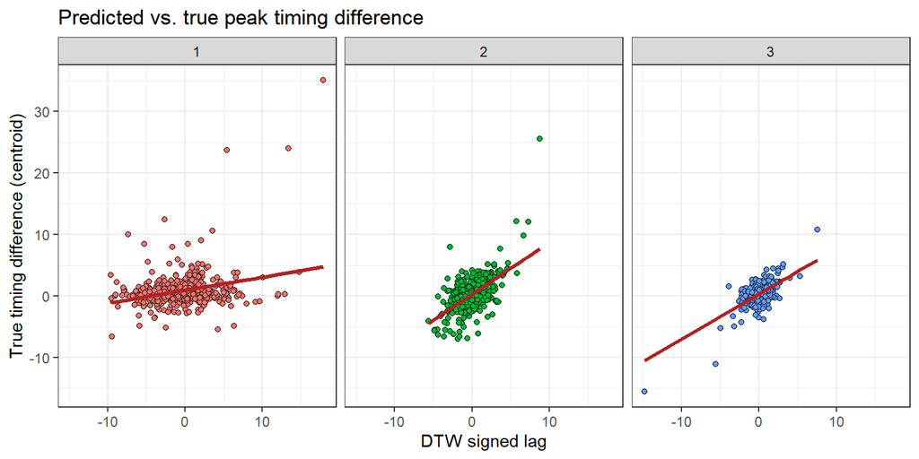

```r
ggplot(diff_peak_time, aes(x = signed_lag, y = centroid_time_diff,
    fill = as.factor(peak_window))) + geom_point(pch = 21, color = "black") +
    geom_line(color = "firebrick", aes(y = pred), lwd = 1.2) +
    theme_bw() + facet_wrap(~peak_window) + labs(x = "DTW signed lag",
    y = "True timing difference (centroid)", title = "Predicted vs. true peak timing difference") +
    theme(legend.position = "none")
```

```r
diff_peak_time_zoom = diff_peak_time |>
    filter(signed_lag >= -10, signed_lag <= 10, centroid_time_diff >=
        -10, centroid_time_diff <= 10)

centroid_lm_zoom = lm(centroid_time_diff ~ signed_lag * factor(peak_window),
    data = diff_peak_time_zoom)

diff_peak_time_zoom$pred <- predict(centroid_lm_zoom, newdata = diff_peak_time_zoom)
```

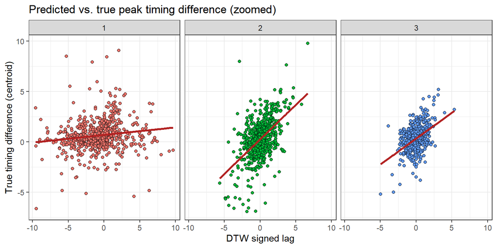

```r
ggplot(diff_peak_time_zoom, aes(x = signed_lag, y = centroid_time_diff,
    fill = as.factor(peak_window))) + geom_point(pch = 21, color = "black") +
    geom_line(color = "firebrick", aes(y = pred), lwd = 1.2) +
    theme_bw() + facet_wrap(~peak_window) + labs(x = "DTW signed lag",
    y = "True timing difference (centroid)", title = "Predicted vs. true peak timing difference (zoomed)") +
    theme(legend.position = "none")
```

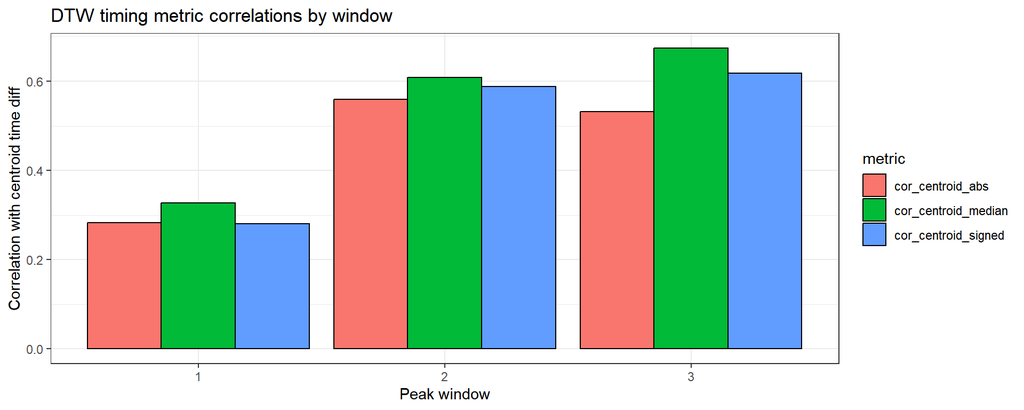

```r
timing_cor_table2 |>
    select(peak_window, cor_centroid_signed, cor_centroid_abs,
        cor_centroid_median) |>
    pivot_longer(-peak_window, names_to = "metric", values_to = "correlation") |>
    ggplot(aes(x = factor(peak_window), y = correlation, fill = metric)) +
    geom_col(position = "dodge", color = "black") + theme_bw() +
    labs(x = "Peak window", y = "Correlation with centroid time diff",
        title = "DTW timing metric correlations by window")
```

# Magnitude

```r
diff_peak_mag = diff_peak_data |>
    filter(state_peak_value > 0, hsa_peak_value > 0, frechet <
        25, truth_mag_ratio < 5)  #, dtw_rmse < 5)
```

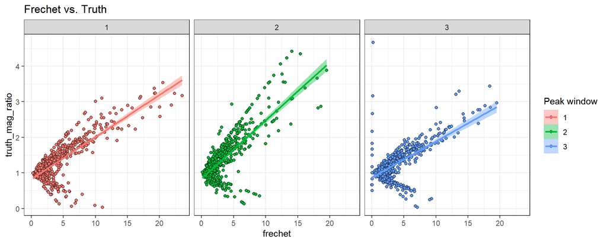

```r
ggplot(diff_peak_mag, aes(x = frechet, y = truth_mag_ratio, fill = as.factor(peak_window))) +
    geom_point(pch = 21, color = "black") + geom_smooth(method = "lm",
    aes(color = as.factor(peak_window))) + facet_wrap(~peak_window) +
    theme_bw() + labs(fill = "Peak window", color = "Peak window",
    title = "Frechet vs. Truth")
```

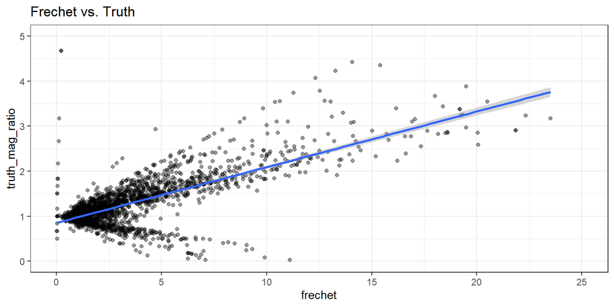

```r
ggplot(diff_peak_mag, aes(x = frechet, y = truth_mag_ratio)) +
    geom_point(color = "black", alpha = 0.4) + geom_smooth(method = "lm") +
    theme_bw() + labs(title = "Frechet vs. Truth") + ylim(0,
    5) + xlim(0, 25)
```

```r
frechet_lm = lm((truth_mag_ratio) ~ (frechet) * factor(peak_window),
    data = diff_peak_mag)

summary(frechet_lm)
```

```
##
## Call:
## lm(formula = (truth_mag_ratio) ~ (frechet) * factor(peak_window),
##     data = diff_peak_mag)
##
## Residuals:
##     Min      1Q  Median      3Q     Max
## -2.1082 -0.1235  0.0531  0.1696  3.7781
##
## Coefficients:
##                               Estimate Std. Error t value Pr(>|t|)
## (Intercept)                   0.823861   0.022354  36.855  < 2e-16 ***
## frechet                       0.118428   0.003970  29.830  < 2e-16 ***
## factor(peak_window)2          0.017108   0.031442   0.544  0.58642
## factor(peak_window)3          0.042221   0.032643   1.293  0.19602
## frechet:factor(peak_window)2  0.045150   0.006383   7.073  2.1e-12 ***
## frechet:factor(peak_window)3 -0.016436   0.006283  -2.616  0.00897 **
## ---
## Signif. codes:  0 '***' 0.001 '**' 0.01 '*' 0.05 '.' 0.1 ' ' 1
##
## Residual standard error: 0.3823 on 1962 degrees of freedom
## Multiple R-squared:  0.5537, Adjusted R-squared:  0.5526
## F-statistic: 486.9 on 5 and 1962 DF,  p-value: < 2.2e-16
```

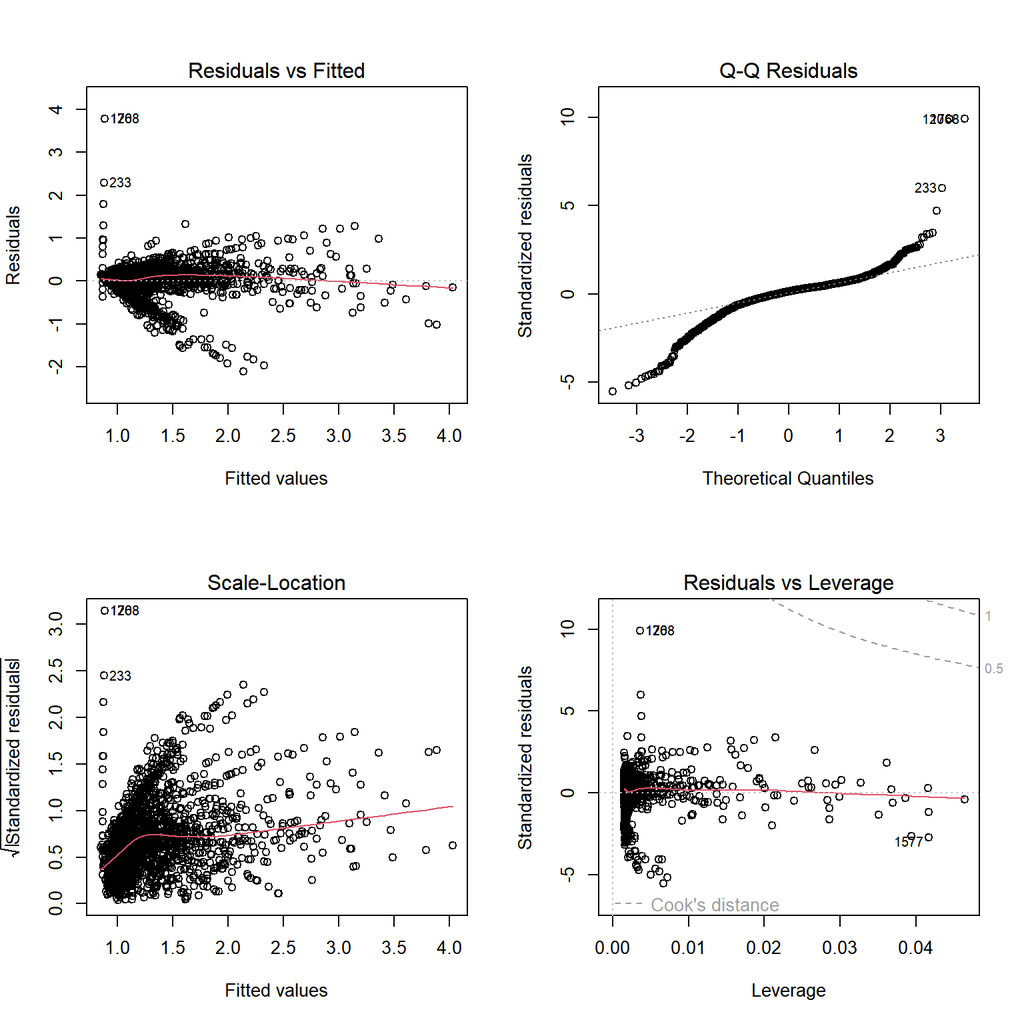

```r
par(mfrow = c(2, 2))
plot(frechet_lm)
```

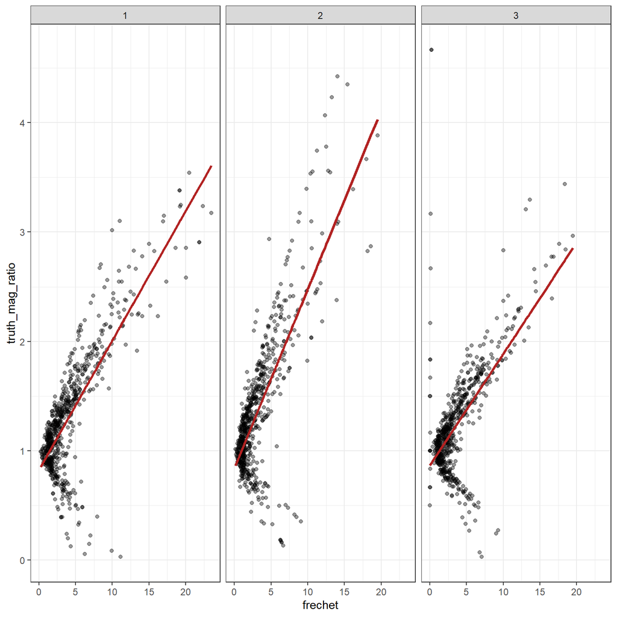

```r
diff_peak_mag$pred <- (predict(frechet_lm))

ggplot(diff_peak_mag, aes(x = frechet, y = truth_mag_ratio)) +
    geom_point(alpha = 0.4) + geom_line(color = "firebrick",
    aes(y = pred), lwd = 1.2) + theme_bw() + facet_wrap(~peak_window)
```

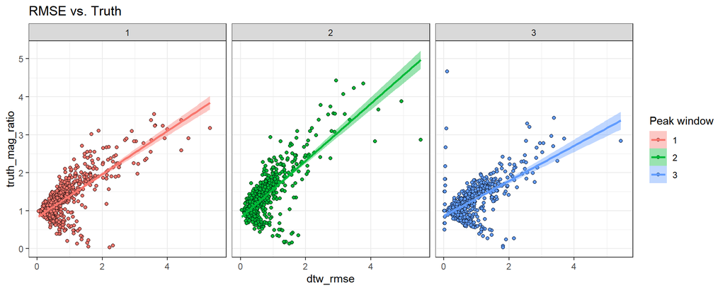

```r
ggplot(diff_peak_mag, aes(x = dtw_rmse, y = truth_mag_ratio,
    fill = as.factor(peak_window))) + geom_point(pch = 21, color = "black") +
    geom_smooth(method = "lm", aes(color = as.factor(peak_window))) +
    facet_wrap(~peak_window) + theme_bw() + labs(fill = "Peak window",
    color = "Peak window", title = "RMSE vs. Truth")
```

```r
magnitude_cor_table = diff_peak_mag |>
    group_by(peak_window) |>
    summarise(cor_dtw_mae = cor(truth_mag_ratio, dtw_mae, use = "complete.obs"),
        cor_dtw_rmse = cor(truth_mag_ratio, dtw_rmse, use = "complete.obs"),
        cor_rmse = cor(truth_mag_ratio, rmse, use = "complete.obs"),
        cor_amp_ratio = cor(truth_mag_ratio, amp_ratio, use = "complete.obs"),
        cor_dtw_amp_ratio = cor(truth_mag_ratio, dtw_amp_ratio,
            use = "complete.obs"), cor_frechet = cor(truth_mag_ratio,
            frechet, use = "complete.obs"), .groups = "drop")

knitr::kable(magnitude_cor_table)
```

| peak_window | cor_dtw_mae | cor_dtw_rmse | cor_rmse | cor_amp_ratio | cor_dtw_amp_ratio | cor_frechet |
| --- | --- | --- | --- | --- | --- | --- |
| 1 | 0.6681948 | 0.7425483 | 0.6321617 | 0.0214656 | -0.1794822 | 0.7934803 |
| 2 | 0.7267771 | 0.7564151 | 0.6454742 | -0.1288494 | -0.3432591 | 0.7642478 |
| 3 | 0.4970125 | 0.5765889 | 0.4473579 | -0.1395358 | -0.2460871 | 0.6273500 |

# US map visualization

```r
us_map = readRDS("../us_map_pop_sf.rds")

lower48 <- setdiff(c(state.name, "District of Columbia"), c("Alaska",
    "Hawaii"))

diff_peak_map = diff_peak_data |>
    filter(signed_lag >= -10, signed_lag <= 10, centroid_time_diff >=
        -10, centroid_time_diff <= 10) |>
    filter(state_peak_value > 0, hsa_peak_value > 0, frechet <
        25, truth_mag_ratio < 5)

# compute per-HSA correlations
hsa_cors = diff_peak_map |>
    group_by(ID, state) |>
    summarise(cor_timing = cor(signed_lag, centroid_time_diff,
        use = "complete.obs"), cor_mag = cor(frechet, truth_mag_ratio,
        use = "complete.obs"), .groups = "drop")

hsa_cors = hsa_cors |>
    mutate(composite = cor_timing + cor_mag)

us_map_plain = us_map |>
    sf::st_drop_geometry() |>
    dplyr::select(-geometry_hsa) |>
    filter(state %in% lower48)

us_map_cors = us_map |>
    filter(hsa_nci_id %in% us_map_plain$hsa_nci_id) |>
    left_join(hsa_cors |>
        rename(hsa_nci_id = ID), by = c("hsa_nci_id", "state"))

# map 1: timing correlation (signed_lag vs
# centroid_time_diff)
timing_map = ggplot() + geom_sf(data = sf::st_set_geometry(sf::st_as_sf(us_map_cors),
    "geometry_hsa"), aes(fill = cor_timing), color = "gray20") +
    geom_sf(data = sf::st_set_geometry(sf::st_as_sf(us_map_cors),
        "geometry"), fill = NA, color = "grey20", linewidth = 0.25) +
    scale_fill_viridis_c(option = "magma", direction = -1, na.value = "white",
        name = "Correlation", limits = c(-1, 1)) + coord_sf() +
    theme_void() + labs(title = "Timing: signed lag vs. centroid time diff")

# map 2: magnitude correlation (frechet vs truth_mag_ratio)
mag_map = ggplot() + geom_sf(data = sf::st_set_geometry(sf::st_as_sf(us_map_cors),
    "geometry_hsa"), aes(fill = cor_mag), color = "gray20") +
    geom_sf(data = sf::st_set_geometry(sf::st_as_sf(us_map_cors),
        "geometry"), fill = NA, color = "grey20", linewidth = 0.25) +
    scale_fill_viridis_c(option = "magma", direction = -1, na.value = "white",
        name = "Correlation", limits = c(-1, 1)) + coord_sf() +
    theme_void() + labs(title = "Magnitude: Frechet vs. truth mag ratio")

# added together map
composite_map = ggplot() + geom_sf(data = sf::st_set_geometry(sf::st_as_sf(us_map_cors),
    "geometry_hsa"), aes(fill = composite), color = "gray20") +
    geom_sf(data = sf::st_set_geometry(sf::st_as_sf(us_map_cors),
        "geometry"), fill = NA, color = "grey20", linewidth = 0.25) +
    scale_fill_viridis_c(option = "plasma", na.value = "white",
        name = "Composite", limits = c(-2, 2)) + coord_sf() +
    theme_void() + labs(title = "Composite correlation (timing + magnitude)")
```

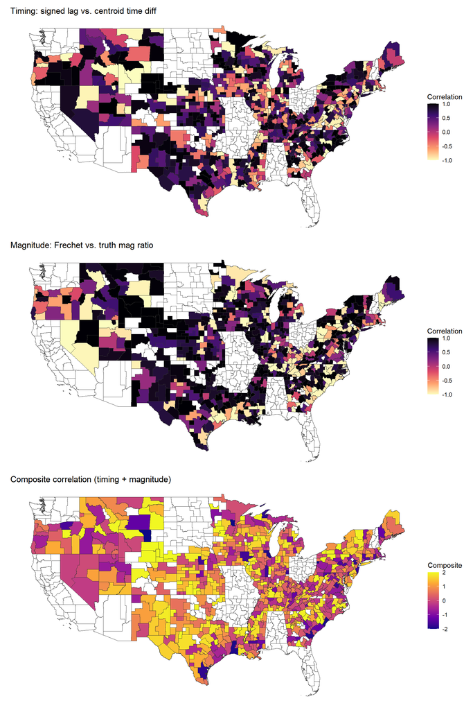

```r
timing_map/mag_map/composite_map
```

# Conclusion

I got timing metrics to work this time by looking at the correlation of the top 20% of magnitudes (instead of one week peaks) and then using that to see how the signed lag would correlate (DTW lag seems to correlate with truth lag) with centroids of the top 20%. Okay, and they seem to have pretty good correlation which holds even after removing outliers. I then plotted three US maps, one for the lag vs centroid diff correlation, the next for frechet vs mag_ratio correlation, and the last US map as a sum to see which HSAs are consistently agreeing with metrics in both time and magnitude. Next week, I might look at R^2 per window and if there are any variables that explain the composite HSA scores in the map above.

maybe also could use cost, look at window 1 in more detail and think about refining, change US map scaling, subset linear regression, filter more strictly, correlation between seasons if lag is consistent or not between states and HSA (do some HSAs always lag, maybe use ground truth and signed_lag), is magnitude ratio always lower or higher than state level across three seasons.